# Linear Regression

MDS. René Rosado González

## Libraries

Load, and install if necessary, the `tidyverse` and `tidymodels` libraries. You will need to have installed the `glmnet` and the `AER` package as well.

```r
# Install - load tidyverse
if(require(tidyverse) == FALSE){
  install.packages('tidyverse')
  library(tidyverse)
}else{
  library(tidyverse)
}
# Install - load tidymodels
if(require(tidymodels) == FALSE){
  install.packages('tidymodels')
  library(tidymodels)
}else{
  library(tidymodels)
}
# Install -glmnet
if(require(glmnet) == FALSE){
  install.packages('glmnet')
}

# Install - AER
if(require(AER) == FALSE){
  install.packages('AER')
}
```

## Dataset

```r
# Load the Teachingcigarettes dataset from the AER package
data('CigarettesSW', package = 'AER')
```

## Exploratory Data Analysis (EDA)

Perform an exploratory data analysis using the `glimpse` and `summary` functions.

```r
## Tidyway
glimpse(CigarettesSW)
```

```
## Rows: 96
## Columns: 9
## $ state      <fct> AL, AR, AZ, CA, CO, CT, DE, FL, GA, IA, ID, IL, IN, KS, KY,…
## $ year       <fct> 1985, 1985, 1985, 1985, 1985, 1985, 1985, 1985, 1985, 1985,…
## $ cpi        <dbl> 1.076, 1.076, 1.076, 1.076, 1.076, 1.076, 1.076, 1.076, 1.0…
## $ population <dbl> 3973000, 2327000, 3184000, 26444000, 3209000, 3201000, 6180…
## $ packs      <dbl> 116.4863, 128.5346, 104.5226, 100.3630, 112.9635, 109.2784,…
## $ income     <dbl> 46014968, 26210736, 43956936, 447102816, 49466672, 60063368…
## $ tax        <dbl> 32.50000, 37.00000, 31.00000, 26.00000, 31.00000, 42.00000,…
## $ price      <dbl> 102.18167, 101.47500, 108.57875, 107.83734, 94.26666, 128.0…
## $ taxs       <dbl> 33.34834, 37.00000, 36.17042, 32.10400, 31.00000, 51.48333,…
```

```r
# Summary
summary(CigarettesSW)
```

```
##      state      year         cpi          population           packs
##  AL     : 2   1985:48   Min.   :1.076   Min.   :  478447   Min.   : 49.27
##  AR     : 2   1995:48   1st Qu.:1.076   1st Qu.: 1622606   1st Qu.: 92.45
##  AZ     : 2             Median :1.300   Median : 3697472   Median :110.16
##  CA     : 2             Mean   :1.300   Mean   : 5168866   Mean   :109.18
##  CO     : 2             3rd Qu.:1.524   3rd Qu.: 5901500   3rd Qu.:123.52
##  CT     : 2             Max.   :1.524   Max.   :31493524   Max.   :197.99
##  (Other):84
##      income               tax            price             taxs
##  Min.   :  6887097   Min.   :18.00   Min.   : 84.97   Min.   : 21.27
##  1st Qu.: 25520384   1st Qu.:31.00   1st Qu.:102.71   1st Qu.: 34.77
##  Median : 61661644   Median :37.00   Median :137.72   Median : 41.05
##  Mean   : 99878736   Mean   :42.68   Mean   :143.45   Mean   : 48.33
##  3rd Qu.:127313964   3rd Qu.:50.88   3rd Qu.:176.15   3rd Qu.: 59.48
##  Max.   :771470144   Max.   :99.00   Max.   :240.85   Max.   :112.63
##
```

Use the `ggpairs` function from the `GGally` package to create a pairplot with the numeric variables.

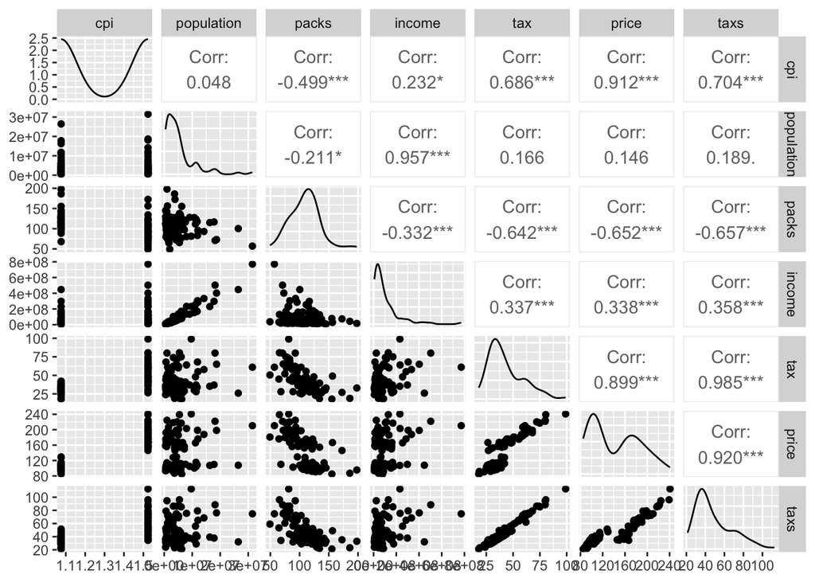

```r
# Install - GGally
if(require(GGally) == FALSE){
  install.packages('GGally')
}

# Pairplot
CigarettesSW %>%
  # Select only numeric columns
  select_if(is.numeric) %>%
  GGally::ggpairs()
```

We will need to deflact values to make them comparable. Calculate de `real_price`,`real_local_tax`, `real_sales_tax`and the `real_income_percapita``

```r
cigarettes = CigarettesSW %>%
  # Transmute date
  transmute(
    # Keep state, year and packs
    year, packs,
    # Deflact real values
    real_price = price / cpi,
    real_local_tax =  tax / cpi,
    real_sales_tax =  taxs / cpi,
    real_income_percapita = income / population / cpi
  )
```

## Linear Regression

Create a model specification for the linear regression using the `tidymodels` framework.

```r
linear_model = linear_reg() %>%
  # Set the engine
  set_engine("glmnet") %>%
  # Set the mode
  set_mode('regression') %>%
  # Set hyperparameters to tune
  set_args(
    penalty = tune(),
    mixture = tune()
    )
```

```r
# Data splitting for samples
set.seed(123)
cigarettes_split = initial_split(
  # Data to split
  data = cigarettes,
  # Proportions
  prop = 0.80,
  # Variable of interest
  strata = packs
)

# Get training and testing samples
cigarettes_training = training(cigarettes_split)
cigarettes_testing = testing(cigarettes_split)
```

Create 3 cross validation folds from the training set.

```r
# Create cross-validation folds
set.seed(123)
cigarettes_folds = vfold_cv(cigarettes_training, v = 3)
```

Create the following recipe to predict the `packs` in function of all other variables.

```r
# Create a recipe
recipe = recipe(
  # Set a formula
  formula = packs ~ .,
  # Set input data
  data = cigarettes_training
) %>%
  step_log(all_numeric()) %>%
  step_dummy(year)
```

```r
# Create a recipe
recipe  %>%
  prep() %>%
  juice()
```

```
## # A tibble: 76 × 6
##    real_price real_local_tax real_sales_tax real_income_percapita packs year_X…¹
##         <dbl>          <dbl>          <dbl>                 <dbl> <dbl>    <dbl>
##  1       4.56           3.26           3.39                  2.41  4.49        0
##  2       4.87           3.76           3.89                  2.61  4.28        1
##  3       4.93           3.69           3.89                  2.78  4.04        1
##  4       4.70           3.36           3.36                  2.79  4.41        1
##  5       4.96           3.88           4.04                  3.04  4.38        1
##  6       4.87           3.80           3.95                  2.82  4.42        1
##  7       4.74           3.45           3.61                  2.66  4.49        1
##  8       4.96           3.90           4.03                  2.91  4.34        1
##  9       5.06           4.17           4.30                  2.76  4.40        1
## 10       4.97           3.86           4.04                  2.78  4.42        1
## # … with 66 more rows, and abbreviated variable name ¹year_X1995
```

Make a workflow object with the recipe and model you just created.

```r
# Create a workflow
linear_workflow = workflow() %>%
  # Add your recipe
  add_recipe(recipe) %>%
  # Add your model
  add_model(linear_model)
```

Perform hyperparameter tuning on the workflow you just created using a `grid` of size 100.

```r
# Get parameters to tune
linear_parameters = linear_workflow %>%
  extract_parameter_set_dials()

# Create a tune grid
set.seed(123)
linear_tuning = tune_grid(
  object = linear_workflow,
  resamples = cigarettes_folds,
  param_info = linear_parameters,
  metrics = metric_set(yardstick::rmse),
  control = control_grid(verbose = TRUE),
  grid = 100
  )
```

Collect the tuning metrics and select the best model based on the `rmse` metric.

```r
# Collegt metrics
tuning_metrics = linear_tuning %>%
  collect_metrics() %>%
  # Arrange form higher mean to lower mean
  arrange(mean)

# Select the best model
best_linear = linear_tuning %>%
  select_best("rmse")

# Print the best model
print(best_linear)
```

```
## # A tibble: 1 × 3
##   penalty mixture .config
##     <dbl>   <dbl> <chr>
## 1 0.00555   0.793 Preprocessor1_Model079
```

Finalize your workflow and make the last fit to collect the performance of the model with the testing sample.

```r
# Finalize the workflow with the best model
final_linear = linear_workflow %>%
  finalize_workflow(best_linear)

# Make the last fit
results_linear = final_linear %>%
  last_fit(
    split = cigarettes_split,
    metrics = metric_set(yardstick::rmse)
    )

# Collect testing metrics
metrics_linear = results_linear %>%
  collect_metrics()

print(metrics_linear)
```

```
## # A tibble: 1 × 4
##   .metric .estimator .estimate .config
##   <chr>   <chr>          <dbl> <chr>
## 1 rmse    standard       0.166 Preprocessor1_Model1
```

Plot the regression plot of the model you just trained

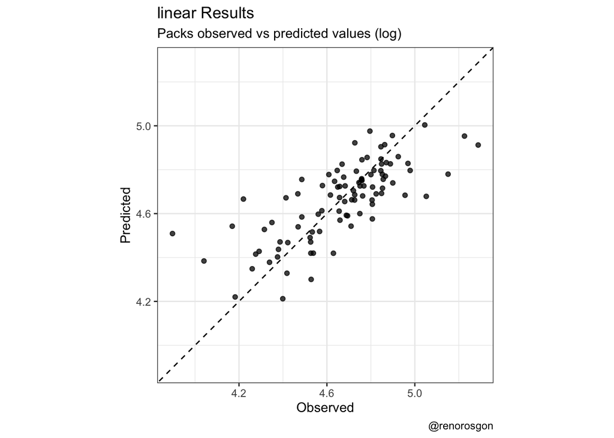

```r
# Extract the trained model
linear_trained = results_linear %>%
  extract_fit_parsnip()

# Preprocessor
cigarettes_baked = recipe %>%
  prep() %>%
  bake(new_data = cigarettes)
# Add predictions
predictions_tb = augment(linear_trained, cigarettes_baked)

# Regression plot (observed vs predicted)
ggplot(predictions_tb, aes(x = packs, y = .pred)) +
  # Create a scatter plot
  geom_point(alpha = 0.75) +
  # Add 45 degree, red, dashhed curve
  geom_abline(linetype = 'dashed') +
  # Make equal axis coordinates
  coord_obs_pred() +
  # Add proper labels
  labs(
    x = 'Observed',
    y = 'Predicted',
    title = 'linear Results',
    subtitle = 'Packs observed vs predicted values (log)',
    caption = '@renorosgon'
  ) +
  # Use a default theme
  theme_bw() +
  # Modify legend attributes using legend.attribute
  theme(
     # Delete legend title
    legend.title = element_blank(),
    # Delete legend background
    legend.background = element_blank(),
    # Delete legend box background
    legend.box.background = element_blank(),
    # Make legend key fill transparent
    legend.key = element_rect(fill = "transparent"),
    # Modify the legend position to de coordinates c(0.1, 0.95)
    legend.position = c(0.1, 0.95),
    # Modify the height of the legend key to 0.5 cm
    legend.key.height = unit(0.5,'cm')
  )
```

As you can see, there are some observations with a better fit (a lower prediction error). Let see if we can understand why it is so. Create the following plots and compare them to see what’s happening.

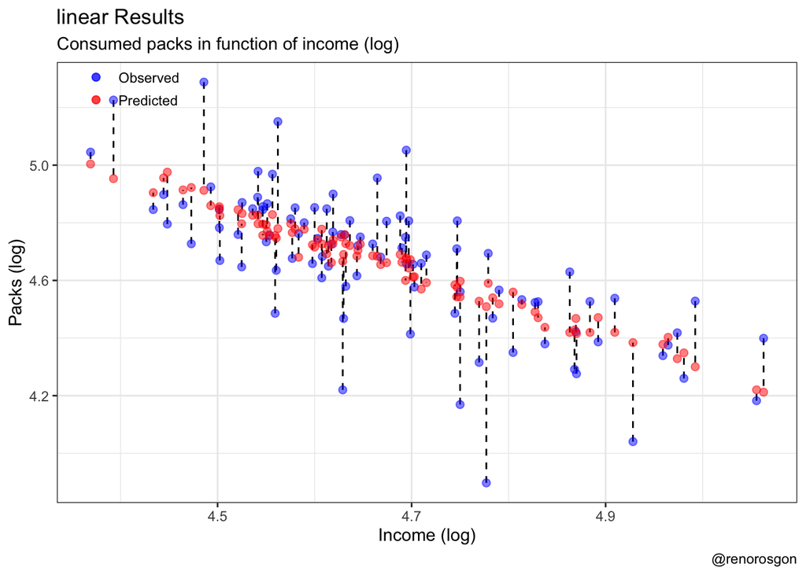

```r
# Create a ggplot with the prediction_tb. Use the income variable in the x axis
ggplot(predictions_tb, aes(x = real_price)) +
  # Add a segment line
  geom_segment(
    aes(
      # Set the income variable in the x axis
      x = real_price, xend = real_price,
      # Set pack as y and .pred as yend
      y = packs, yend = .pred
      ),
    # Set the linetype to dashed
    linetype = 'dashed'
    ) +
  # Add a scatter plot with the packs variable. Color the dots as 'Observed'
  geom_point(
    aes(y = packs, col = 'Observed'),
    alpha = 0.5, size = 2
    ) +
  # Add a scatter plot with the .pred variable. Color the dots as 'Predicted'
  geom_point(
    aes(y = .pred, col = 'Predicted'),
    alpha = 0.5 , size = 2
    ) +
  # Set color to blue and red
  scale_color_manual(values = c('blue','red')) +
  # Add proper labels
  labs(
    x = 'Income (log)',
    y = 'Packs (log)',
    title = 'linear Results',
    subtitle = 'Consumed packs in function of income (log)',
    caption = '@renorosgon'
  ) +
  # Use a default theme
  theme_bw() +
  # Modify legend attributes using legend.attribute
  theme(
     # Delete legend title
    legend.title = element_blank(),
    # Delete legend background
    legend.background = element_blank(),
    # Delete legend box background
    legend.box.background = element_blank(),
    # Make legend key fill transparent
    legend.key = element_rect(fill = "transparent"),
    # Modify the legend position to de coordinates c(0.1, 0.95)
    legend.position = c(0.1, 0.95),
    # Modify the height of the legend key to 0.5 cm
    legend.key.height = unit(0.5,'cm')
  )
```

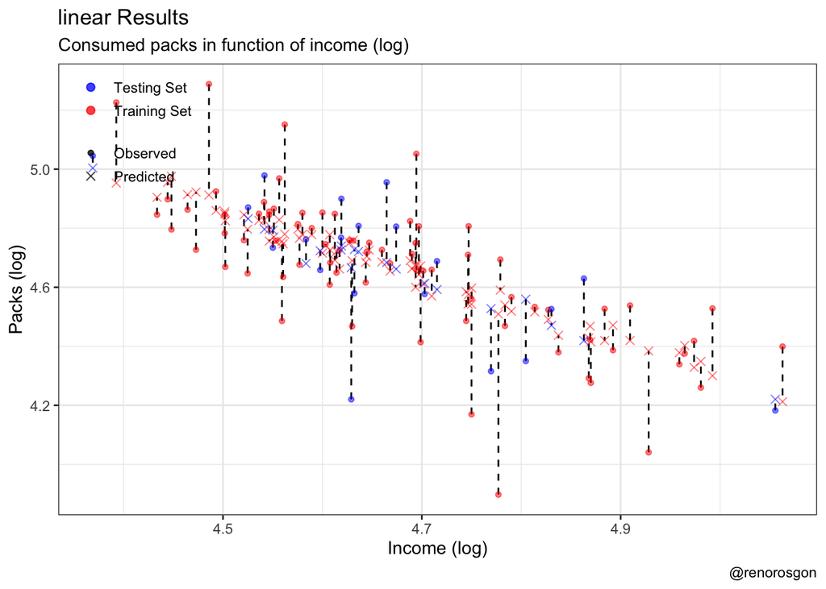

```r
# Plot decision boundatires
training = recipe %>%
  prep() %>%
  juice() %>%
  augment(x = linear_trained) %>%
  mutate(set = 'Training Set')
testing = recipe %>%
  prep() %>%
  bake(new_data = cigarettes_testing) %>%
  augment(x = linear_trained) %>%
  mutate(set = 'Testing Set')

predictions_tb = bind_rows(training, testing)

ggplot(predictions_tb, aes(x = real_price)) +
  # Add a segment line
  geom_segment(
    aes(
      # Set the income variable in the x axis
      x = real_price, xend = real_price,
      # Set pack as y and .pred as yend
      y = packs, yend = .pred
      ),
    # Set the linetype to dashed
    linetype = 'dashed'
    )  +
  # Add a scatter plot with the packs variable. Color the dots as 'Observed'
  geom_point(
    aes(y = packs, shape = 'Observed', col = set),
    alpha = 0.5, size = 2
    ) +
  # Add a scatter plot with the .pred variable. Color the dots as 'Predicted'
  geom_point(
    aes(y = .pred, shape = 'Predicted', col = set),
    alpha = 0.5 , size = 2
    ) +
  # Set color to blue and red
  scale_color_manual(values = c('blue','red')) +
  # Add proper labels
  # Modify shape
  scale_shape_manual(values = c(20,4)) +
  labs(
    x = 'Income (log)',
    y = 'Packs (log)',
    title = 'linear Results',
    subtitle = 'Consumed packs in function of income (log)',
    caption = '@renorosgon'
  ) +
  # Use a default theme
  theme_bw() +
  # Modify legend attributes using legend.attribute
  theme(
     # Delete legend title
    legend.title = element_blank(),
    # Delete legend background
    legend.background = element_blank(),
    # Delete legend box background
    legend.box.background = element_blank(),
    # Make legend key fill transparent
    legend.key = element_rect(fill = "transparent"),
    # Modify the legend position to de coordinates c(0.1, 0.95)
    legend.position = c(0.1, 0.85),
    # Modify the height of the legend key to 0.5 cm
    legend.key.height = unit(0.5,'cm'),
    # Modify the height of the legend key to 0.5 cm
    legend.spacing.y = unit(0.015,'cm')
  )
```